# oPDF tutorial

`oPDF` is a code for modelling the phase space distribution of steady-state tracers in spherical potentials. For more information, check the [website](http://kambrian.github.io/oPDF).

Please consult the science paper on how it works.

You can use this tutorial interactively in ipython notebook by running

```
ipython notebook
```

from the root directory of the oPDF code. If that does not work, then simply continue reading this document as a html.

## Getting Started

### prerequisites

The oPDF code depends on the following libraries:

- C libraries
  - [GSL](http://www.gnu.org/software/gsl/)
  - [HDF5](http://www.hdfgroup.org/HDF5/)
- Python libraries
  - numpy, scipy, matplotlib
  - iminuit (optional, only needed if you want to do NFW-likelihood fit to the density profile of dark matter.)

You can customize the makefile to specify how to compile and link against the GSL and HDF5 libraries, by specifying the `GSLINC,GSLLIB,HDFINC,HDFLIB` flags. ###build the library under the root directory of the code, run

```
make
```

This will generate the library `liboPDF.so`, the backend of the python module. Now you are all set up for the analysis. Open your python shell in the code directory, and get ready for the modelling. If you want to get rid of all the `*.o` files, you can clean them by

```
make clean
```

### Prepare the data files

Compulsory datasets in a data file:

- `x, shape=[nx3], datatype=float32`. The position of each particle.
- `v, shape=[nx3], datatyep=float32`. The velocity of each particle.

Optional datasets:

- `PartMass, [nx1] or 1, float32`. This is the mass of particles. Assuming 1 if not specified.
- `SubID, [nx1], int32`. This is the subhalo id of each particle, for examination of the effects of subhaloes during the analysis.
- `HaloID, [nx1], int32`. This is the host halo id of each particles.

The units of the data can be specified when running the code.

*Note*: to construct a tracer sample for a halo, do not use FoF particles alone. Instead, make a spherical selection by including all the particles inside a given radius. These will include FoF particles, background particles, and particles from other FoFs. FoF selection should be avoided because it is an arbitrary linking of particles according to their separations, but not dynamics.

## A simple example: Fit the mock halo with RBinLike

### Load the data

```python
from oPDF import *
```

```python
datafile="../data/mockhalo.hdf5"
FullSample=Tracer(datafile)
Sample=FullSample.copy(0,1000)
```

```
30000 <oPDF.LP_Particle_t object at 0x51bf9e0>
```

This will load the data into FullSample, and make a subsample of 1000 particles from the FullSample. You may want to do your analysis with the full sample. We extract the subsample just for illustrution purpose, to speed up the calculation in this tutorial.

### Perform the fitting.

Now let's fit the data with the radial binned likelihood estimator with 10 logarithmic radial bins.

```python
Estimators.RBinLike.nbin=10
x,fval,status=Sample.dyn_fit(Estimators.RBinLike)
print x,fval,status
```

```
[ 161.8486416    19.83133738] 5014.14688084 1
```

In one or two minutes, you will get the results above, where

- `x` is the best-fitting parameters
- `fval` is the maximum log-likelihood value
- `status` =1 means fitting is successful, =0 means fit failed.

That's it! You have got the best-fitting \(M=161.8\times10^{10} M_\odot\) and \(c=19.83\). ### Estimate significances How does that compare to the real parameters of \(M=183.5017\times 10^{10}M_\odot\), \(c=16.1560\)? Not too far, but let's check the likelihood ratio of the two models

```python
x0=[183.5017,16.1560]
f0=Sample.likelihood(x0, Estimators.RBinLike)
likerat=2*(fval-f0)
print likerat
```

```
1.0933322551
```

So we got a likelihood ratio of 1.09. How significant is that? According to Wilks' theorem, if the data follows the null model (with the real parameters), then the likelihood ratio between the best-fit and the null would follow a \(\chi^2\) distribution. Since we have two free parameters, we should compare our likelihood ratio to a \(\chi^2(dof=2)\) distribution. We can obtain the pval from the survival function of a \(\chi^2\) distribution, and convert that to a Guassian significance level. This is automatically done by the Chi2Sig() utility function

```python
from myutils import Chi2Sig
significance=Chi2Sig(likerat, dof=2)
print significance
```

```
0.555026554617
```

So the best-fitting differs from the real parameters by \(0.56\sigma\), which is not significant at all. In other words, the best-fitting parameters are quite consistent with the real parameters!

### Confidence Contour

Following the same philosophy for the significance levels, we can start to define confidence contours formed by points that differ from the best-fitting parameters by a given significance level. This is done by scanning a likelihood surface and then converting it to a significance surface. For example, below we scan \(20\times20\) grids around the best-fitting parameters `x`, inside a box spanning from `log10(x)-dx` to `log10(x)+dx` in each dimension. For the confidence levels of RBinLike, we can provide the maximum likelihood value that we obtained above, to save the function from searching for maxlike itself. Be prepared that the scan can be slow.

```python
m,c,sig=Sample.scan_confidence(Estimators.RBinLike, x, ngrids=[20,20], dx=[0.5,0.5], logscale=True, maxlike=fval)
```

Now let's plot them in units of the real parameter values:

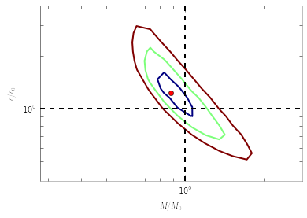

```python
plt.contour(m/x0[0],c/x0[1],sig,levels=[1,2,3]) #1,2,3sigma contours.
plt.plot(x[0]/x0[0],x[1]/x0[1],'ro') #the best-fitting
plt.plot(plt.xlim(),[1,1], 'k--', [1,1], plt.ylim(),  'k--')# the real parameters
plt.loglog()
plt.xlabel(r'$M/M_0$')
plt.ylabel(r'$c/c_0$')
```

### Phase Images

How does the data look in \((\theta,E,L)\) space? We can create images showing the distribution of particles in these coordinates. These images give a direct visualization of how uniformly the tracer are distributed along \(\theta\)-direction, on different (\(E,L\)) orbits. They are quite useful for spotting deviations from steady-stateness in particular regions in phase space, for example, to examine local deviations caused by subhaloes.

To avoid having too few particles in each pixel we will start by drawing a larger sample as NewSample, and then plot the images adopting the real potential with parameters `x0`.

```python
NewSample=FullSample.copy(0,20000)
```

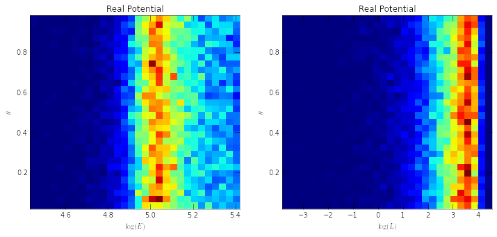

```python
plt.figure(figsize=(12,5))
plt.subplot(1,2,1)
NewSample.phase_image(x0, proxy='E')
plt.title('Real Potential')
plt.subplot(1,2,2)
NewSample.phase_image(x0, proxy='L')
plt.title('Real Potential')
```

We can see that the particle distribution is indeed uniform (roughly given the current resolution) along the \(\theta\)-direction, irrespective of the energy and angular momentum.

### TS profiles

If you want a more quantitative view of how much deviation there is at each \(E\), \(L\) or even \(r\), you can plot the mean phase deviation or AD distance (Test Statistics, or TS) inside different \((E,L,r)\) bins.

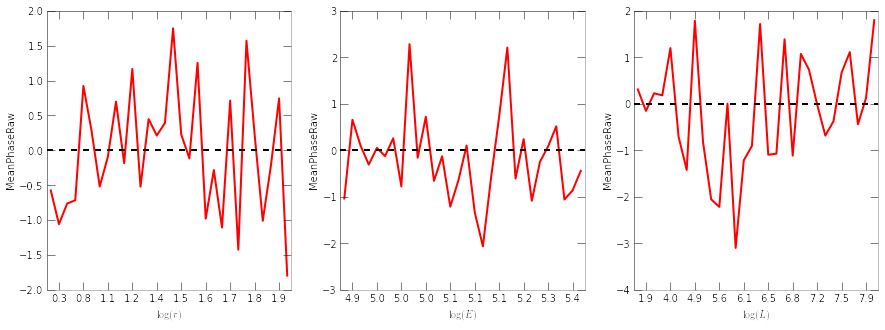

```python
nbin=30
x0=[183.5017,16.1560]
plt.figure(figsize=(15,5))
for i,proxy in enumerate('rEL'):
    plt.subplot(1,3,i+1)
    NewSample.plot_TSprof(x0, proxy, nbin)
    plt.plot(plt.xlim(), [0,0], 'k--')
```

## Customizing the analysis

### Estimators

There are several predefined estimators to choose from when you need an estimator as a parameter. These are listed as members of `Estimators`. In most cases, you can freely choose from the following when an estimator is required.

- Estimators.RBinLike
- Estimators.AD
- Estimators.MeanPhase
- Estimators.MeanPhaseRaw (same as MeanPhase but returns the un-squared mean phase deviation, so it is a standard normal variable instead of a chi-square for MeanPhase).

For RBinLike, you can also customize the number of radial bins and whether to bin in linear or log scales. For example, the following will change the RBinLike to use 20 linear bins.

```python
Estimators.RBinLike.nbin=20
Estimators.RBinLike.logscale=False
```

### units

The system of units is specified in three fundamental units: Mass[\(M_\odot/h\)], Length[kpc\(/h\)], Velocity[km/s]. You can query the current units with

```python
Globals.get_units()
```

```
Mass  : 7300000000.0 Msun/h
Length: 0.73 kpc/h
Vel   : 1.0 km/s
```

```
(7300000000.0, 0.73, 1.0)
```

If you want to change the system of units, you must do it immediately after importing the `oPDF` module, to avoid inconsistency with units of previously loaded tracers. For example, to change the units to (1e10Msun/h,kpc/h,km/s),

```python
from oPDF import *
Globals.set_units(1e10,1,1)
```

The user should only use Globals.set_units() to change the units, which automatically updates several interal constants related to units. Never try to change the internal unit variables (e.g., Globals.units.MassInMsunh) manually.

### cosmology

The cosmology parameters (\(\Omega_{M0}\), \(\Omega_{\Lambda0}\))can be accessed through

```python
print Globals.cosmology.OmegaM0, Globals.cosmology.OmegaL0
```

```
0.3 0.7
```

To change the cosmology to (0.25, 0.75), simply do

```python
Globals.cosmology.OmegaM0=0.25
Globals.cosmology.OmegaL0=0.75
```

Again this is advised to be done in the beginning, to avoid inconsistency in the calculations.

### parametrization of the potential

The default parameterization of the potential is a NFW potential with mass and concentration parameters. You can change the parametrization of the halo associated with your tracer. For example, if you want to fit for \((\rho_s,r_s)\) instead of (\(M,c\)), then

```python
Sample.halo.set_type(halotype=HaloTypes.NFWRhosRs)
```

Available types are listed as members of the `HaloTypes` objects, including:

- HaloTypes.NFWMC: NFW halo parametrized by \((M,c)\)
- HaloTypes.NFWRhosRs: NFW, \((\rho_s,r_s)\)
- HaloTypes.NFWPotsRs: NFW, (\(\psi_s, r_s\)), with \(\psi_s=4\pi G\rho_s r_s^2\).
- HaloTypes.CorePotsRs: Cored Generalized NFW Potential (inner density slope=0), parametrized by (\(\psi_s,r_s\))
- HaloTypes.CoreRhosRs: Cored GNFW, \((\rho_s,r_s)\)
- HaloTypes.TMPMC: Template profile, \((M,c)\) parametrization
- HaloTypes.TMPPotScaleRScale: Template, \(\psi_s/\psi_{s0}, r_s/r_{s0}\)

To use template profiles, you have to creates them first, in the form of (\(r,\psi,\rho(\lt r)\)) arrays and the real \(r_s\) parameter to be added to C/TemplateData.h. You need to recompile the C library once this is done. PotentialProf.py can help you in generating the templates from DM distributions.

If you use template profiles, you also need to specify the template id, to tell the code which template in TemplateData.h to use. For example,

```python
Sample.halo.set_type(halotype=HaloTypes.TMPPotScaleRScale, TMPid=5)
```

You can also change the virial definition and redshift of the halo, for example:

```python
Sample.halo.set_type(virtype=VirTypes.B200, redshift=0.1)
```

When fitting for the potential, it is always a good choice to adjust the scales of parameters so that the numerical values of the parameters are of order 1. oPDF allows you to change the scale of the parameters. The physical values of the parameters will be the raw parameters times the scale of parameters. By default, the scales are all set to unity. We can change them as

```python
Sample.halo.set_type(scales=[100,10])
```

Now if we fit the Sample again with the RBinLike estimator, instead of `x=[ 161.8 19.8]`, we will get `x=[1.618 1.98]` as the best fit, but the physical values are not changed.

#### Halos

Each tracer is associated with a halo. You can also work with a seperate halo object. There are several methods associated with a halo object. You can set_type(), set_param(), get the mass and potential profiles

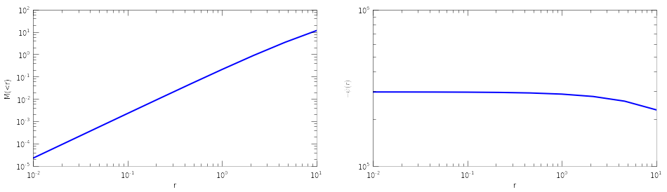

```python
halo=Halo(halotype=HaloTypes.NFWMC)
halo.set_param([180,13])
r=np.logspace(-2,1,10)
plt.figure(figsize=(16,4))
plt.subplot(121)
plt.loglog(r, halo.mass(r))
plt.xlabel('r')
plt.ylabel('M(<r)')
plt.subplot(122)
plt.loglog(r, -halo.pot(r))
plt.xlabel('r')
plt.ylabel(r'$-\psi(r)$')
```

### selecting and cutting

This applies a radial cut from 1 to 100 in system unit :

```python
Sample.radial_cut(1,100)
```

This creates a subsample by selecting high angular momentum (L>1e4) particles:

```python
SubSample=Sample.select(Sample.data['L']>1e4)
```

All the particle data can be accessed from the record array Sample.data. You can do similar selections (and many other operations) on any available fields of the data. Have a look at the datatype or `Particle_t._fields_` to see the available fields

```python
print Sample.data.dtype.names
```

```
('haloid', 'subid', 'flag', 'w', 'r', 'K', 'L2', 'L', 'x', 'v', 'E', 'T', 'vr', 'theta', 'rlim')
```

Note:

- The `w` field is the particle mass in units of the average particle mass. The average particle mass is `Sample.mP`. These are all ones if no particle mass is given in the datafile.
- the `haloid` and `subid` fields are only filled if you have `SubID` and `HaloID` datasets in the datafile when loading.
- The `E`,`theta` and `rlim` fields are the energy, phase-angle, and radial limits (peri and apo-center distances) of the orbits. These depend on the potential, and are only filled when you have done some calculation in a halo or have filled them explicitly with the set_phase() function, e.g.,

```python
Sample.set_phase(x0)
print Sample.data['E'][10]
print Sample.data['theta'][35]
```

```
9201829.25741
0.982207688183
```

### Extending the code

- To add new types of potential
- in C/halo.h: add your HaloType identifier in HaloType_t
- in C/halo.c:
  - write your halo initializer in halo_set_param()
  - write your potential function in halo_pot()
  - optionally, write your cumulative mass profile in halo_mass(), and add any initilization in halo_set_type() if needed.
- in oPDF.py:
  - add your newly defined halotype to the following line `HaloTypes=NamedEnum(...`
- To add new template profiles
- Generate your template in the form of (\(r,\psi,\rho(\lt r)\)) arrays, and append to C/PotentialTemplate in TemplateData.h
- Append the scale radius of the new template to TemplateScale in C/TemplateData.h. This is only used if you want to use TMPMC parametrization. In this case the scale radius must be the radius where the logrithmic slope of density equals to -2. If you only want to use TMPPotScaleRScale parametrization, you can put any arbitrary value here.
- To add new estimators
- check C/models.c

You need to recompile the C library once this is done. PotentialProf.py can help you in generating the templates from DM distributions.